# Practical Machine Learning

Toni Rosati

April 23, 2016

### Background

Using devices such as Jawbone Up, Nike FuelBand, and Fitbit it is now possible to collect a large amount of data about personal activity relatively inexpensively. These type of devices are part of the quantified self movement – a group of enthusiasts who take measurements about themselves regularly to improve their health, to find patterns in their behavior, or because they are tech geeks. One thing that people regularly do is quantify how much of a particular activity they do, but they rarely quantify how well they do it. In this project, your goal will be to use data from accelerometers on the belt, forearm, arm, and dumbell of 6 participants. They were asked to perform barbell lifts correctly and incorrectly in 5 different ways. More information is available from the website here: http://groupware.les.inf.puc-rio.br/har (see the section on the Weight Lifting Exercise Dataset).

```r
library(caret)
library(rpart)
library(rpart.plot)
library(randomForest)
library(knitr)
```

### Data

The data for this project come from this source: http://groupware.les.inf.puc-rio.br/har. If you use the document you create for this class for any purpose please cite them as they have been very generous in allowing their data to be used for this kind of assignment.

The training data for this project are available here: https://d396qusza40orc.cloudfront.net/predmachlearn/pml-training.csv The test data are available here: https://d396qusza40orc.cloudfront.net/predmachlearn/pml-testing.csv

```r
#training dataset
whole_train<-read.csv("pml-training.csv", na.strings=c("NA","#DIV/0!",""))
#testing dataset
testdata<-read.csv("pml-testing.csv", na.strings=c("NA","#DIV/0!",""))
```

### Cleaning the Data

It is unnecessary to have data that are precalculated, so I have removed the columns labeled “max_”, “min_”, “kurtosis”, “skewness”, “stddev”, “var_”, “avg_”, and “amplitude”. This is done for both the training set and the testing set.

```r
#remove anything that says max_ min_ kurtosis skewness stddev var_ avg_ amplitude
train<-whole_train[,c(8:11,37:49,60:68,84:86,102,113:124,140,151:160)]
test<-testdata[,c(8:11,37:49,60:68,84:86,102,113:124,140,151:160)]
```

### Creating Training Subsets

Since the training dataset is large enough, I’ve subset it into a training and a probe set. This will allow me to validate accuracy of the model before applying it to the test set.

```r
inTrainPart<- createDataPartition(y=train$classe, p=.5, list=FALSE)
train1<-train[inTrainPart,]
train2<-train[-inTrainPart,]
#The two subsets have equivalent Classe
summary(train1$classe)
```

```
##    A    B    C    D    E
## 2790 1899 1711 1608 1804
```

```r
summary(train2$classe)
```

```
##    A    B    C    D    E
## 2790 1898 1711 1608 1803
```

### Fit a model using Recursive Partitioning and Regression Trees (r_part)

Based on the Coursera forums, I’ve opted to build models using rpart and random forest. I’m starting with rpart because the computational time is much shorter.

```r
set.seed(459)
fit1_rpart<-train(classe~., data=train1, method="rpart")
fit1_rpart
```

```
## CART
##
## 9812 samples
##   52 predictor
##    5 classes: 'A', 'B', 'C', 'D', 'E'
##
## No pre-processing
## Resampling: Bootstrapped (25 reps)
## Summary of sample sizes: 9812, 9812, 9812, 9812, 9812, 9812, ...
## Resampling results across tuning parameters:
##
##   cp          Accuracy   Kappa       Accuracy SD  Kappa SD
##   0.03574480  0.5035986  0.35047809  0.03112679   0.04923510
##   0.05985949  0.4090051  0.19540278  0.05950623   0.10046277
##   0.11734549  0.3140128  0.04438142  0.03831717   0.06043108
##
## Accuracy was used to select the optimal model using  the largest value.
## The final value used for the model was cp = 0.0357448.
```

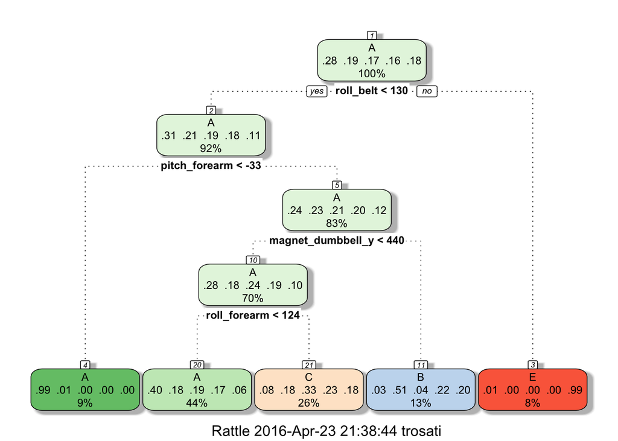

```r
fancyRpartPlot(fit1_rpart$finalModel)
```

```r
fit2_rpart <- train(train1$classe ~ .,  preProcess=c("center", "scale"), data = train1, method="rpart")
print(fit2_rpart, digits=3)
```

```
## CART
##
## 9812 samples
##   52 predictor
##    5 classes: 'A', 'B', 'C', 'D', 'E'
##
## Pre-processing: centered (52), scaled (52)
## Resampling: Bootstrapped (25 reps)
## Summary of sample sizes: 9812, 9812, 9812, 9812, 9812, 9812, ...
## Resampling results across tuning parameters:
##
##   cp      Accuracy  Kappa   Accuracy SD  Kappa SD
##   0.0357  0.510     0.3614  0.0373       0.0589
##   0.0599  0.407     0.1942  0.0605       0.1006
##   0.1173  0.330     0.0693  0.0405       0.0627
##
## Accuracy was used to select the optimal model using  the largest value.
## The final value used for the model was cp = 0.0357.
```

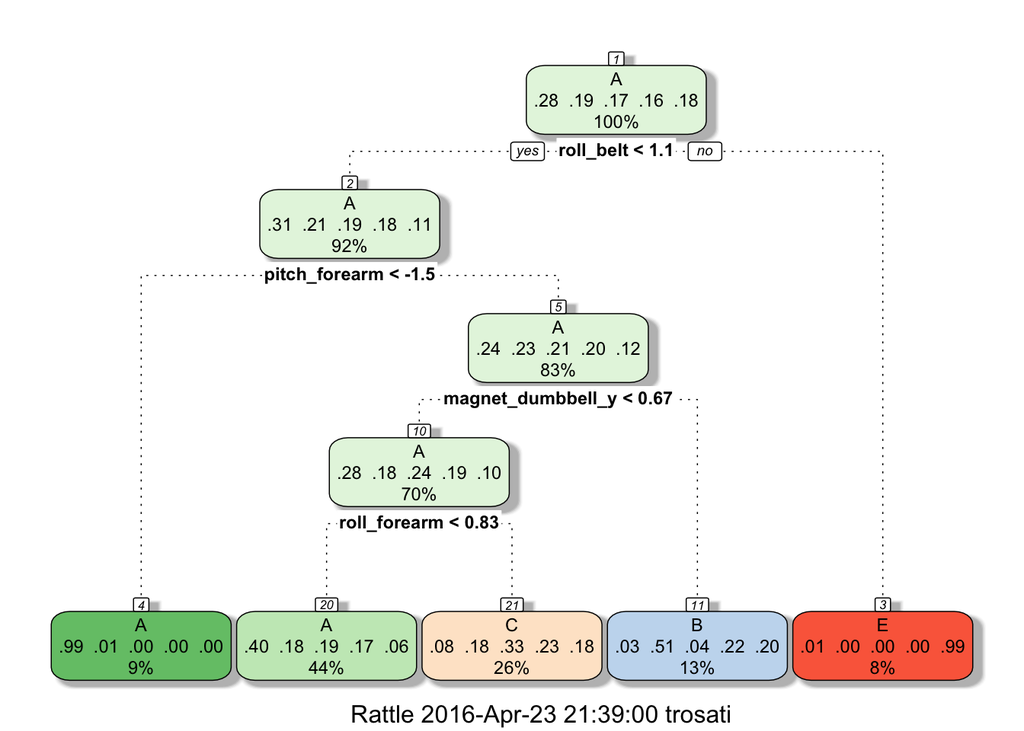

```r
fancyRpartPlot(fit2_rpart$finalModel)
```

```r
fit3_rpart <- train(classe ~ .,  trControl=trainControl(method = "cv", number = 4), data = train1, method="rpart")
print(fit3_rpart, digits=3)
```

```
## CART
##
## 9812 samples
##   52 predictor
##    5 classes: 'A', 'B', 'C', 'D', 'E'
##
## No pre-processing
## Resampling: Cross-Validated (4 fold)
## Summary of sample sizes: 7358, 7358, 7361, 7359
## Resampling results across tuning parameters:
##
##   cp      Accuracy  Kappa   Accuracy SD  Kappa SD
##   0.0357  0.506     0.3539  0.0105       0.0135
##   0.0599  0.430     0.2309  0.0724       0.1211
##   0.1173  0.323     0.0593  0.0449       0.0685
##
## Accuracy was used to select the optimal model using  the largest value.
## The final value used for the model was cp = 0.0357.
```

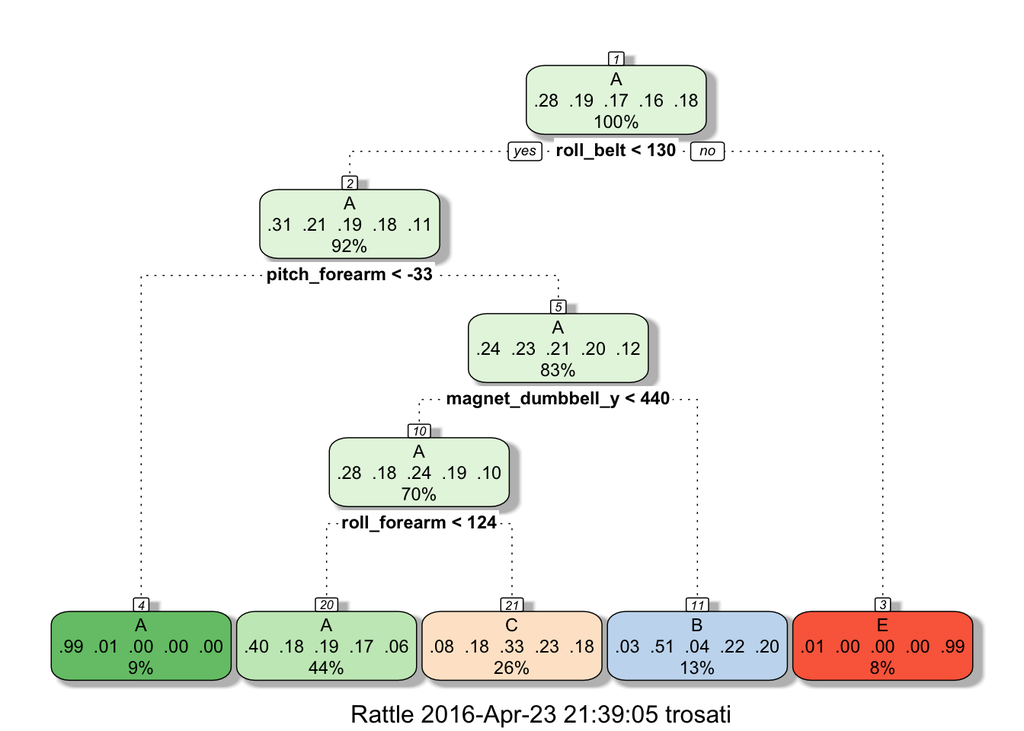

```r
fancyRpartPlot(fit3_rpart$finalModel)
```